Econometrics and Statistics (520K)

# Econometric Methods in Business and Economics

Practical Class (Winter 24/25)

by Domenic Franjic

# Exercise Sheet No 01

California Test Score Data Set

We want to analyze student performance and class size. For this we use the data set `CASchool_01_data.txt`. The data set contains the variables described in the table below for school districts in California.

| Variable | Description |
| --- | --- |
| $students$ | Total enrollment. |
| $teachers$ | Number of teachers. |
| $read$ | Average reading score. |
| $math$ | Average math score. |

## Set-Up

1) Create your (working) directory

Create a new folder on your computer in which you can save all necessary files, i.e., the data set, the R *script* with the implementation of your analysis and the R *helper function script* with some helper functions provided by us.

This folder, i.e., the path or directory of this folder, will be your so-called working directory.

2) Download the data set

Download the data sets `CASchools_01_data.txt` from ILIAS or by using the link below:

[Download `CASchools_01_data.txt`](https://ilias.uni-hohenheim.de/goto.php?target=file_1523858_download&client_id=UHOH)

Save the data set into your (working) directory.

3) Prepare *script*

Open a new R *script* and save it into into your (working) directory.

Run the following code chunk to prepare your R *script*, i.e., to clear the work space and set your working directory.

```r
# Clear workspace
rm(list = ls(all = TRUE))
# Set working directory
setwd(".../set/your/working/directory/...")
```

4) Install/load *packages* and download/save/include *helper function script*

Step 1) Install all relevant R *packages* and download and save the R *script* `r_helper_functions.R` from ILIAS by running the following code chunk.

```r
# Download R-helper functions
source("https://ilias.uni-hohenheim.de/data/UHOH/lm_data/lm_1856939/MA_EconometricMethods_WiSe2324_PracticalClass/r-scripts/prepare_r_packages_and_helper_functions.R")
```

*Note*, the required R *packages* are `"moments"`, `"sandwich"`, `"lmtest"`, `"lmtest"`, `"car"`, `"plm"`, `"ivreg"`, `"dynlm"`, `"forecast"`, `"urca"`.

Step 2) Include the R *script* `r_helper_functions.R` into your R *script* by running the following code chunk.

```r
# Include R-helper functions
source("r_helper_functions.R")
```

*Note*, more information on the helper functions can be found here.

## Task a)

Load the data set into R and familiarize yourself with the structure of the data.

Load data set

```r
# load the data set
cas.dat <- read.table(file = "CASchools_01_data.txt",
                      header = TRUE,
                      sep = ",",
                      colClasses = c("numeric","numeric","numeric","numeric"))
```

- Use a *statement*, consisting of a *function*, e.g., `read.table()` and the *assignment* notation, i.e., `<-` to define a data object, e.g., `cas.dat`.
- Use the *function* `read.table()` to load the data set.
- Use the *function* `help(read.table)` to open the help page for the *function* `read.table`.

Structure of the data set

```r
# list the first six observations
head(cas.dat)
# return the structure
str(cas.dat)
```

```
##   students teachers  read  math
## 1      195    10.90 691.6 690.0
## 2      240    11.15 660.5 661.9
## 3     1550    82.90 636.3 650.9
## 4      243    14.00 651.9 643.5
## 5     1335    71.50 641.8 639.9
## 6      137     6.40 605.7 605.4
```

```
## 'data.frame':    420 obs. of  4 variables:
##  $ students: num  195 240 1550 243 1335 ...
##  $ teachers: num  10.9 11.1 82.9 14 71.5 ...
##  $ read    : num  692 660 636 652 642 ...
##  $ math    : num  690 662 651 644 640 ...
```

Use the *functions* `head()` and `str()` to get an overview of the structure of the data set.

- `cas.dat` is a object of class `'data.frame'`, which is the most common data structure in the implementations here.
- All the variable are of *mode* `'numeric'`.
- Note, this is not surprising as we defined the columns/variables to be “numeric” when we loaded the data set using the *function* `read.table()` with the option `colClasses = c("numeric","numeric","numeric","numeric")` above.
- The *data frame* contains 420 observations for four variables.
- The variables are $students$, $teachers$, $read$ and $math$.

*Add your interpretation here!*

## Task b)

Replicate and interpret the summary statistics depicted in Table 2 of the Exercise Sheet.

Replicate summary statistics

```r
# compute sample averages
avg.stu <- mean(cas.dat$students)
avg.tea <- mean(cas.dat$teachers)
avg.rea <- mean(cas.dat$read)
avg.mat <- mean(cas.dat$math)
# compute sample standard deviations
sd.stu <- sd(cas.dat$students)
sd.tea <- sd(cas.dat$teachers)
sd.rea <- sd(cas.dat$read)
sd.mat <- sd(cas.dat$math)
# set up a vector of percentiles and compute the percentiles
per <- c(0.10, 0.25, 0.4, 0.5, 0.6, 0.75, 0.9)
per.stu <- quantile(cas.dat$students, per)
per.tea <- quantile(cas.dat$teachers, per)
per.rea <- quantile(cas.dat$read, per)
per.mat <- quantile(cas.dat$math, per)
```

- Use the `$` notation to access a variable of a *data frame*, e.g, here, `cas.dat$students`.
- Use the *functions* `mean()`, `sd()`, and `quantile()` to calculate the *mean*, *standard deviation*, and *quantiles* of variables.

Collect results

```r
# gather everything in a data.frame
dis.sum.01 <- data.frame(avg = c(avg.stu, avg.tea, avg.rea, avg.mat),
                         sd  = c(sd.stu, sd.tea, sd.rea, sd.mat),
                         per = rbind(per.stu, per.tea, per.rea, per.mat))
dis.sum.01
```

```
##               avg         sd per.10.  per.25. per.40. per.50.  per.60.  per.75.  per.90.
## per.stu 2628.7929 3913.10498  164.00 379.0000 592.400 950.500 1665.400 3008.000 7119.500
## per.tea  129.0674  187.91268    9.00  19.6625  33.372  48.565   87.592  146.350  332.174
## per.rea  654.9705   20.10798  629.38 640.4000 651.600 655.750  660.800  668.725  680.530
## per.mat  653.3426   18.75420  629.69 639.3750 647.700 652.450  657.780  665.850  676.760
```

Use the *function* `data.frame()` to create a new *data frame*, here, with the summary statistics for each variable.

|  | Average | SD | Percentile 10% | Percentile 25% | Percentile 40% | Percentile 50% | Percentile 60% | Percentile 75% | Percentile 90% |
| --- | --- | --- | --- | --- | --- | --- | --- | --- | --- |
| students | 2628.79 | 3913.10 | 164.00 | 379.00 | 592.40 | 950.50 | 1665.40 | 3008.00 | 7119.50 |
| teachers | 129.07 | 187.91 | 9.00 | 19.66 | 33.37 | 48.56 | 87.59 | 146.35 | 332.17 |
| reading | 654.97 | 20.11 | 629.38 | 640.40 | 651.60 | 655.75 | 660.80 | 668.73 | 680.53 |
| math | 653.34 | 18.75 | 629.69 | 639.38 | 647.70 | 652.45 | 657.78 | 665.85 | 676.76 |

For $\underline{students}$ (e.g.)

- Average: 2628.79
- Standard deviation: 3913.1
- 50th Percentile: 950.5 ($<$ 2628.79: positively/right-skewed)
- 10th Percentile: 164

*Add your interpretation here!*

Illustration No 01: Histograms

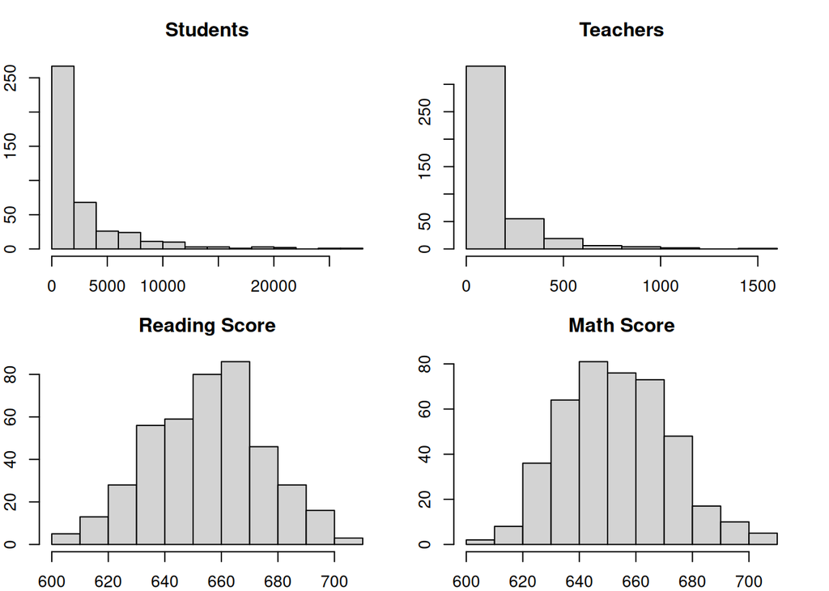

```r
# plot parameters
par(mfrow = c(2,2),
    mar = c(2, 2, 3, 2))
# histograms
hist(cas.dat$students, main = "Students", xlab = "")
hist(cas.dat$teachers, main = "Teachers", xlab = "")
hist(cas.dat$read, main = "Reading Score", xlab = "")
hist(cas.dat$math, main = "Math Score", xlab = "")
```

Illustration No 02: Boxplots

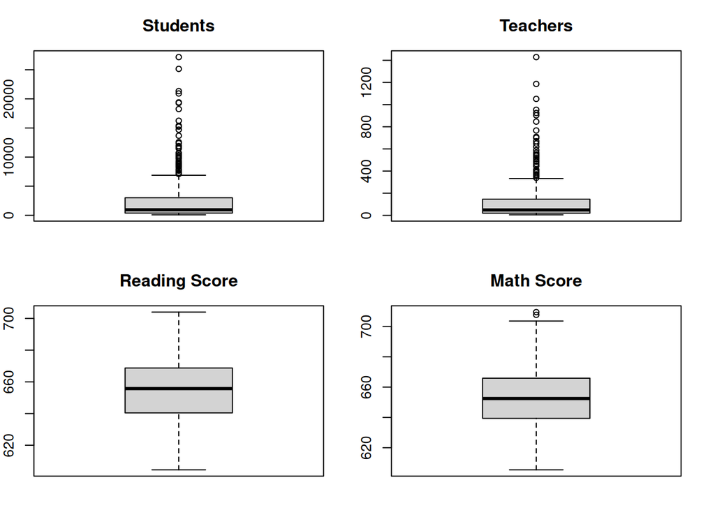

```r
# plot parameters
par(mfrow=c(2, 2),
    mar=c(2, 2, 3, 2))
# histograms
boxplot(cas.dat$students, main = "Students", xlab = "")
boxplot(cas.dat$teachers, main = "Teachers", xlab = "")
boxplot(cas.dat$read, main = "Reading Score", xlab = "")
boxplot(cas.dat$math, main = "Math Score", xlab = "")
```

General

- Use the *function* `par()` with the options `mfrow` and `mar`.
  - Use the option `mfrow=c(2,2)` to split the plot window, here, into two rows and two columns, to show plots side-by-side.
  - Use the option `mar=c(2,2,3,2)` to set the margins on the bottom, left, top, and right of the plot window.
- Use the *function* `hist()` and `boxplot` to illustrate the distribution using a histogram and a boxplot, respectively.

Boxplots

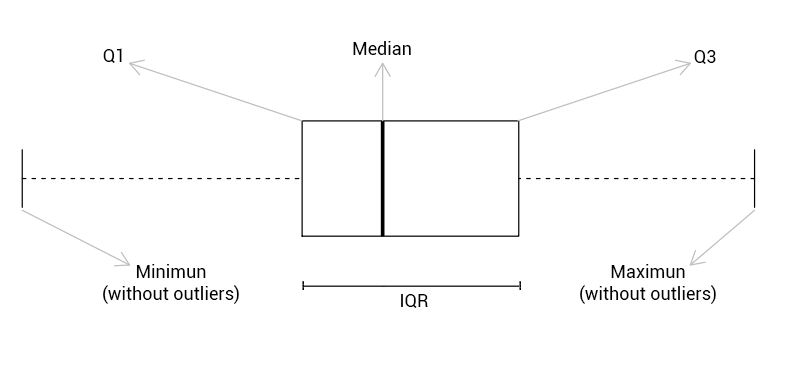

Source: https://r-coder.com/boxplot-r/

- Outlier are observation that are very distant from the rest of the data and illustrated as unfilled dots.
- Positive outlier: $\,\,\, >Q_{3}+1.5*IQR$
- Negative outlier: $<Q_{1}-1.5*IQR$
- With:
  - $Q_{1}$: First quartile
  - $Q_{3}$: Third quartile
  - $IQR=Q_{3}-Q_{1}$

## Task c)

Construct the variable $score$ as the arithmetic mean of the test score for reading and the score of the math test and the variable $STR$ as the number of students per teachers.

Construct and inspect constructed variables

```r
# compute STR and append it to cas.dat
cas.dat$STR <- cas.dat$students/cas.dat$teachers
# compute TestScore and append it to cas.dat
cas.dat$score <- (cas.dat$read + cas.dat$math)/2
# list the first six observations
head(cas.dat)
```

```
##   students teachers  read  math      STR  score
## 1      195    10.90 691.6 690.0 17.88991 690.80
## 2      240    11.15 660.5 661.9 21.52466 661.20
## 3     1550    82.90 636.3 650.9 18.69723 643.60
## 4      243    14.00 651.9 643.5 17.35714 647.70
## 5     1335    71.50 641.8 639.9 18.67133 640.85
## 6      137     6.40 605.7 605.4 21.40625 605.55
```

A new variable e.g., `nev.var`, can be added to a *data frame* using the `$` notation and the assignment notation `<-`.

## Task d)

Provide a summary of the distribution of test scores and student-teacher ratios based on the constructed variables similar to Table 2 above and Table 4.2 in Stock and Watson (2020).

Calculate summary statistics

```r
# compute sample averages of STR and score
avg.str <- mean(cas.dat$STR)
avg.sco <- mean(cas.dat$score)
# compute sample standard deviations of STR and score
sd.str <- sd(cas.dat$STR)
sd.sco <- sd(cas.dat$score)
# set up a vector of percentiles and compute the percentiles
per <- c(0.10, 0.25, 0.4, 0.5, 0.6, 0.75, 0.9)
per.str <- quantile(cas.dat$STR, per)
per.sco <- quantile(cas.dat$score, per)
```

Collect results

```r
# gather everything in a data.frame
dis.sum.02 <- data.frame(avg = c(avg.str, avg.sco),
                         sd = c(sd.str, sd.sco),
                         per = rbind(per.str, per.sco))
dis.sum.02
```

```
##               avg        sd  per.10.   per.25.   per.40.   per.50.  per.60.   per.75.   per.90.
## per.str  19.64043  1.891812  17.3486  18.58236  19.26618  19.72321  20.0783  20.87181  21.86741
## per.sco 654.15655 19.053347 630.3950 640.05000 649.06999 654.45000 659.4000 666.66249 678.85999
```

|  | Average | SD | Percentile 10% | Percentile 25% | Percentile 40% | Percentile 50% | Percentile 60% | Percentile 75% | Percentile 90% |
| --- | --- | --- | --- | --- | --- | --- | --- | --- | --- |
| STR | 19.64 | 1.89 | 17.35 | 18.58 | 19.27 | 19.72 | 20.08 | 20.87 | 21.87 |
| score | 654.16 | 19.05 | 630.40 | 640.05 | 649.07 | 654.45 | 659.40 | 666.66 | 678.86 |

For $\underline{STR}$

- Average: 19.64
- Standard deviation: 1.89
- 50th Percentile: 19.72 ($\approx$ 19.64: symmetric)
- 10th Percentile: 17.35

For $\underline{score}$

- Average: 654.16
- Standard deviation: 19.05
- 50th Percentile: 654.45 ($\approx$ 654.16: symmetric)
- 10th Percentile: 630.4

*Add your interpretation here!*

Illustration No 01: Histograms

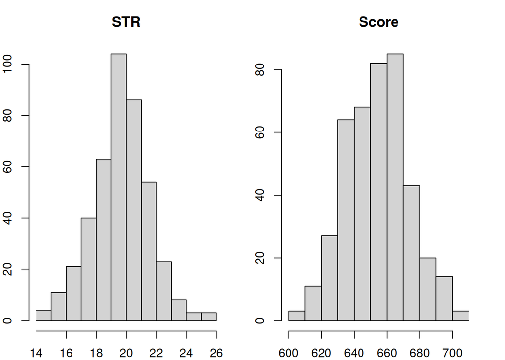

```r
# plot parameters
par(mfrow=c(1, 2),
    mar=c(2, 2, 3, 2))
# histograms
hist(cas.dat$STR, main = "STR", xlab = "")
hist(cas.dat$score, main = "Score", xlab = "")
```

Illustration No 02: Boxplots

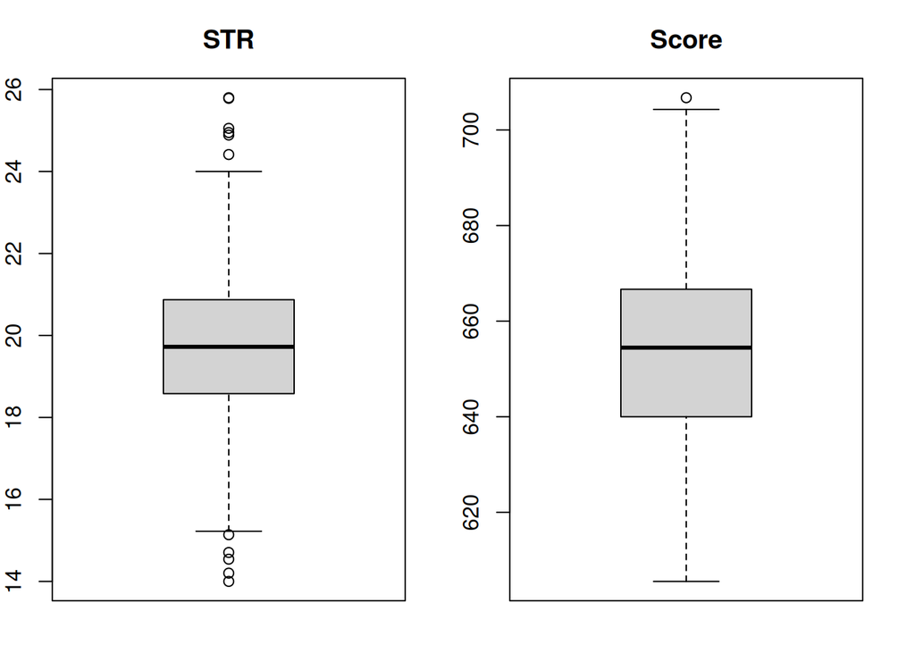

```r
# plot parameters
par(mfrow=c(1, 2),
    mar=c(2, 2, 3, 2))
# boxplots
boxplot(cas.dat$STR, main = "STR", xlab = "")
boxplot(cas.dat$score, main = "Score", xlab = "")
```

## Task e)

Provide a scatter plot of test scores vs. student-teacher ratios similar to Figure 4.2 in Stock and Watson (2020). Is there a relationship between the two variables?

Scatter Plot

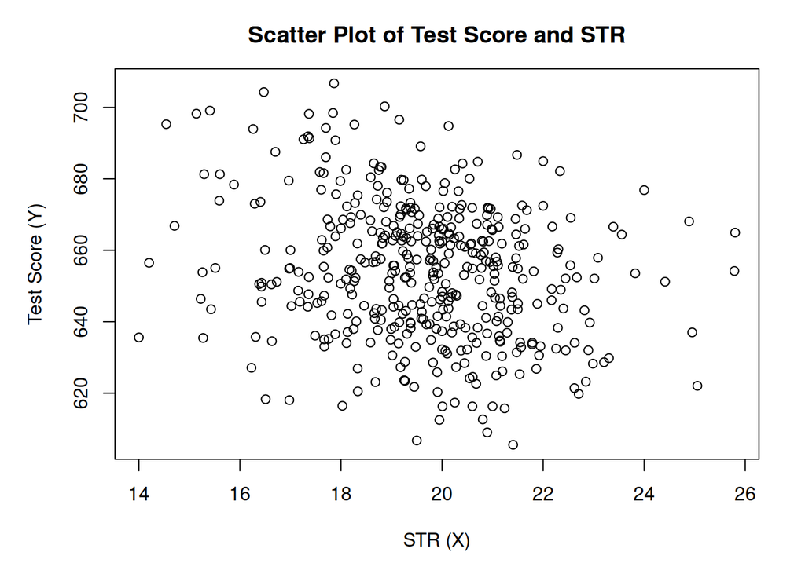

```r
# plot parameters
par(mfrow=c(1, 1),
    mar=c(5, 5, 3, 2))
# scatterplot
plot(cas.dat$STR, cas.dat$score,
     main = "Scatter Plot of Test Score and STR",
     xlab = "STR (X)",
     ylab = "Test Score (Y)")
```

- Larger classes in this sample tend to have lower test scores.
- Other factors seem to ensure that the observations are not perfectly along a straight line.

*Add your interpretation here!*

- Use the *function* `plot()` to construct a generic X-Y plot.
- Use the *function* `hist()` and `boxplot` to illustrate the distribution using a histogram and a boxplot, respectively.

Correlation coefficient

```r
# sample correlation
cor.str.sco <- cor(cas.dat$STR, cas.dat$score)
cor.str.sco
```

```
## [1] -0.2263627
```

Use the *function* `cor()` to calculate the sample correlation.

- Sample correlation coefficient: -0.23
- Weak negative linear relationship
- By “weak negative linear relationship” we mean something like the variation of $score$ explained/predicted by variation in $STR$ (more details follow during the course!)

*Add your interpretation here!*

Back To *Start* of *Practical Class*